# Python Crash Course for Java Developers

**Mario Kahlhofer** | mario.kahlhofer@dynatrace.com  
Softwareentwicklung 1 | JKU Linz | WS 2020/21

**Code & Slides: [`github.com/blu3r4y/python-for-java-developers`](https://github.com/blu3r4y/python-for-java-developers)**

[figure not shown]

(c) https://xkcd.com/353

## Agenda

- Why Python?
- Installation
- Syntax
- Data Types
- Collections
- Input and Output
- Examples, Examples, Examples
- Functions
- Classes
- Code Organization
- Libraries
- Zen of Python

## Literature

### Books

- Sarda, Deepak. **Python for the Busy Java Developer**. Apress, 2017. DOI: 10.1007/978-1-4842-3234-7
  - *Note: Still uses the already obsolete Python 2 syntax!*

### Official Documentation

- docs.python.org/3/faq/programming.html
  - "How can I achieve X?"
- docs.python.org/3/faq/design.html
  - "Why are certain things the way they are in Python?"
- docs.python.org/3/library
  - "What functions does the standard library provide me with?"

### Cheat Sheets

- gto76.github.io/python-cheatsheet
- pythoncheatsheet.org
- [pythonsheets.com](https://www.pythonsheets.com/)

# 💎 Why Python?

- a mature, **general-purpose, object-oriented, dynamically-typed** programming language *(Java is statically-typed)*
- released in 1991 *(Java was released in 1995)*
- one of the dominating languages in machine learning, statistics, and data analytics
- popular alternative to MATLAB or Octave
- gaining in popularity year after year

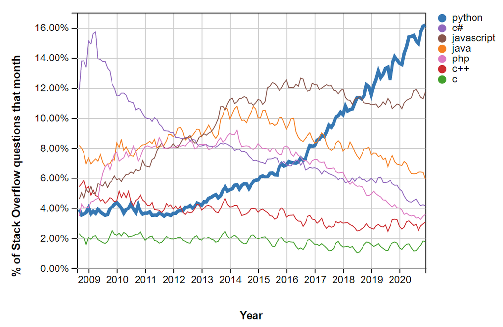

(c) https://insights.stackoverflow.com/trends

## Comparison to Java

### Similarities

- general-purpose, object-oriented, garbage-collected, large standard library

### Differences

- **dynamically-typed**, and not strongly-typed *(type checks will only happen at runtime)*
- **interpreted with CPython**, and not just-in-time compiled with a JVM *("more flexibility, but slower execution times")*
- **interactive mode** provided out of the box *("you are looking at it right now!")*

# 💎 Installation

- Go to [python.org](https://www.python.org/) and install the 64-bit version of Python 3.7, 3.8 or 3.9
  - *As of January 2021, you will still mostly see Python 3.7 or 3.8 during your studies ...*
  - **Do NOT use Python 2.7 or older anymore!**
- You could directly use Python from the command line with the `python` command
- Python comes with a package-manager called `pip`
  - *We will do our examples inside Jupyter notebooks, which you can install with `pip install jupyter`*
  - *Those packages will be downloaded from [pypi.org](http://pypi.org/)*
- The most popular IDEs are [IntelliJ PyCharm](https://www.jetbrains.com/pycharm/) or [Visual Studio Code](https://code.visualstudio.com/)

### A Note about Anaconda

- If you intend to use lots of scientific packages, you should use [anaconda.com](https://www.anaconda.com/products/individual)
  - *Packages like `numpy`, `scipy`, `sympy`, `tensorflow` from Anaconda often work out of the box, especially on Windows*
- Anaconda comes with the package-manager `conda`
  - *Works similar to `pip`, e.g., use `conda install jupyter`*

# Follow along this notebook by visiting [`t.ly/zqaN`](https://t.ly/zqaN)

## Jupyter Notebooks

### Installation

- Install with `pip install jupyter` or `python -m pip install jupyter`
- Start with `jupyter-notebook` or `python -m notebook`
  - Optionally specify a start-up directory with `jupyter-notebook --notebook-dir <path>`

### Purpose

- A mix of of code and documentation, usually for prototyping or documentation purposes
- Allows you to write mathematical formulas next to your code

$$ e^{j x} = \cos{x} + j \sin{x} $$

### Usage

- Have code or markdown cells (for documentation)
- Run cells with the button or `CTRL + ENTER` (stays at the cell) or `SHIFT + ENTER` (moves to the next cell)
- Restart the kernel to delete all variables and start fresh
- Use auto-completion with the `TAB` key

Let's do our first simple calculation with Python

```python
1 + 2
```

```
3
```

Let's assign the value of `1` to the variable `x`

```python
x = 1
```

... and print the contents of the variable `x`

```python
x
```

```
1
```

What do you think will happen if we write multiple instructions?

```python
1 + 1
2 * 3
```

```
6
```

Everything will be evaluated, but you will only ever see the result of your last line, unless you use the explicit `print` function

```python
y = 1 + 1
z = 2 * 3

print(y)
print(z)
```

```
2
6
```

Everything we do here will be "remembered", even if you remove some cells. This is what we initially meant with "interactive mode".

To start over, restart the kernel. Note that you can chose to keep or clear your outputs when restarting the kernel.

```python
# print(y)
```

Oh ... we almost forgot: Here is the obligatory "Hello World" program with Python

```python
print("Hello World")
```

```
Hello World
```

# 💎 Syntax

```python
%%script false --no-raise-error # ignore this Java code block

List<Integer> numbers = Arrays.asList(1, -10, 20, 11, 19, 0, -5, -1000, 100, 7);

int maximum = numbers.get(0);

// let's find the maximum
for (int number : numbers) {
    if (number > maximum) {
        maximum = number;
    }
}

System.out.println("The maximum value is " + maximum);
```

```
Couldn't find program: 'false'
```

```python
numbers = [1, -10, 20, 11, 19, 0, -5, -1000, 100, 7]

maximum = numbers[0]

# let's find the maximum
for number in numbers:
    if number > maximum:
        maximum = number

print("The maximum value is", maximum)
```

```
The maximum value is 100
```

**What do we notice here?**

- There are no semicolons `;`
- There are no types
- There are no braces `{` `}`, but blocks that are started by a colon `:`
- There are no parentheses `(` `)` around the expressions
- A list - one of many built-in data collections in Python - is initialized with square brackets (actually, there are no arrays in Python)
- The `for` and `if` syntax is slightly different
- Comments are written with the hashtag `#` symbol

# 💎 Data Types

We will not take a look at the different data types in Python.  
However, as you will see, there is no need to specify them explicitly.

## Numeric Types

There are only three numeric types in Python.  
`float` types are internally represented as `double` data types, like you know from Java.

In contrast to Java, there is NO differentiation into `short`, `int`, `long`, `float`, `double` types.

See also https://docs.python.org/3/library/stdtypes.html#numeric-types-int-float-complex

```python
my_int = 5
my_float = 3.141
my_complex = 1 + 2j

# there are also some useful ways to write numbers
us_national_debt = 27.8e+12
ascii_symbol = 0x3f
input_bitmask = 0b1011_1001
```

Furthermore, integers do have arbitrary precision. And you can still do math with them.  
And you can use a `_` sign as a thousand separator if you wish.

```python
lightyear_to_meter = 9_460_730_472_580_800
min_milky_way_diameter = 170_000 * lightyear_to_meter

print("The milky way is at least", min_milky_way_diameter, "meters in diameter")
```

```
The milky way is at least 1608324180338736000000 meters in diameter
```

```python
distance_to_proxima_centauri = 4.24 * lightyear_to_meter

print("The star Proxima Centauri is", distance_to_proxima_centauri, "meters away from the earth")
```

```
The star Proxima Centauri is 4.011349720374259e+16 meters away from the earth
```

### Mathematical Expressions

This is just a brief teaser. We will do some more later on.

```python
x = 10.5
y = -3
```

```python
print("x + y =", x + y)
print("x - y =", x - y)
print("x * y =", x * y)
```

```
x + y = 7.5
x - y = 13.5
x * y = -31.5
```

```python
print("x / y =", x / y)
print("x // y =", x // y)  # integer division
print("x % y =", x % y)    # modulo
```

```
x / y = -3.5
x // y = -4.0
x % y = -1.5
```

```python
print("abs(y) =", abs(y))
print("int(x) =", int(x))                # convert to integer
print("float(y) =", float(y))            # convert to float
print("complex(x, y) =", complex(x, y))  # convert to complex
```

```
abs(y) = 3
int(x) = 10
float(y) = -3.0
complex(x, y) = (10.5-3j)
```

```python
print()
print("pow(x, 3) =", pow(x, 3))  # exponentiation
print("x ** 3 =", x ** 3)        # exponentiation (alternative)
```

```
pow(x, 3) = 1157.625
x ** 3 = 1157.625
```

```python
# let's load our first package that holds a lot of mathematical functions
import math
```

```python
math.sqrt(16)
```

```
4.0
```

```python
math.factorial(5)
```

```
120
```

```python
math.log(math.e)
```

```
1.0
```

```python
math.sin(math.pi / 2)
```

```
1.0
```

## Text Types

Strings in Python are immutable, just like in Java.  
This means, if you modify, or concatenate strings, new memory will be allocated.

```python
first_string = "Hello World"
second_string = 'Hello Python'

multi_line_strings = """This can even
hold line breaks
now"""
```

## Boolean Types

```python
yea = True
nay = False
```

### Boolean Expressions

```python
x = True
y = False
```

```python
print("x | y =", x | y)  # bitwise or
print("x & y =", x & y)  # bitwise and
print("x ^ y =", x ^ y)  # exclusive or
```

```
x | y = True
x & y = False
x ^ y = True
```

```python
# this is especially useful for some binary computations

port    = 0b1011_1011
bitmask = 0b0010_0000

result = port & (bitmask >> 1)

print(result)
print(f"{result:08b}")  # we learn more about formatting in the next section ...
```

```
16
00010000
```